# R Markdown in aller Kürze

# Warum R Markdown?

**R Markdown** ist eine Kombination aus der wunderbaren Programmiersprache **R** und der beliebten – weil so simplen – Auszeichnungsprache **Markdown**.

## Was kann das?

Folgende wenige Zeilen genügen, ein html-Dokument mit eingebettetem R-Code zu generieren:

````
---
title: Ein Beispiel
output: html_document
---

Dies ist ein vollständiges -- wenn auch simples -- **R Markdown** Dokument.

Es enthält **R** Code:

 ```{r}
 hundert_zufallszahlen <- rnorm(100)
 plot(hundert_zufallszahlen)
 ```
````

Das Ergebnis ist eine html-Seite, wie sie jeder Web-Browser öffnen kann, ob sie nun auf deiner Festplatte oder auf einem Webserver liegt. HTML ist ein wahnsinnig vielseitiges Format und kann beinahe jeden erdenklichen Inhalt haben.

Eine winzige Änderung in der Zeile

```
output: html_document
```

ganz oben zu

```
output: pdf_document
```

oder zu

```
output: word_document
```

bewirkt, dass die Ausgabe stattdessen als statisches pdf- oder Word-Dokument erfolgt.

Es gibt noch eine ganze Reihe weiterer interessanter Ausgabe-Formate (z.B. interaktive Tutorials wie [dieses](http://195.201.24.35:3838/RasGIStutorial_german/)), aber auch weniger interessante (wie PowerPoint). Auch dieses Tutorial wurde mit **R Markdown** geschrieben.

Neugierig geworden?

## Markdown — Was ist das überhaupt?

**Markdown** ist eine vereinfachte *Auszeichnungssprache*, also eine maschinenlesbare Sprache für die Gliederung und Formatierung von Texten (und anderen Daten). Mit *Auszeichnungssprachen* wird beschrieben, wie Textabschnitte (Zeichen, Wörter, Absätze) dargestellt werden sollen, z.B., ob es sich um eine Überschrift handelt, einen Link oder eine Fußnote. Die Beschreibung erfolgt dabei in Textform, wobei ein erklärtes Ziel von **Markdown** ist, dass bereits der Quellcode leicht lesbar ist. Andere, deutlich weniger simple Auszeichnungssprachen sind z.B. HTML oder LaTeX.

### Ein Beispiel sagt mehr als 76 Worte

#### Normaler Text und Absätze:

```
Normaler Text wird so dargestellt wie eingegeben und
automatisch umgebrochen, falls nötig.
Eine neue Zeile im Quelltext erzeugt dabei keinen(!)
Zeilenumbruch.

Eine Leerzeile erzeugt immer einen neuen Absatz.
```

Normaler Text wird so dargestellt wie eingegeben und automatisch umgebrochen, falls nötig. Eine neue Zeile im Quelltext erzeugt dabei keinen(!) Zeilenumbruch.

Eine Leerzeile erzeugt immer einen neuen Absatz.

#### Hervorhebungen

```
*Kursiv*, **Fett** und ***Fett kursiv***
```

*Kursiv*, **Fett** und *Fett kursiv*

#### Aufzählungen

```
* Ein Punkt in einer ungeordneten Liste
* Ein weiterer Punkt in einer ungeordneten Liste
    * Ein Unterpunkt, um vier Leerzeichen eingerückt
 * Statt * funktionieren auch + oder -
    + das vorangestellte Zeichen spielt dabei keine Rolle
    - lediglich die Einrückung zählt
```

- Ein Punkt in einer ungeordneten Liste
- Ein weiterer Punkt in einer ungeordneten Liste
  - Ein Unterpunkt, um vier Leerzeichen eingerückt
- Statt * funktionieren auch + oder -
  - das vorangestellte Zeichen spielt dabei keine Rolle
  - lediglich die Einrückung zählt

#### Überschriften

Überschriften und Unterüberschriften werden durch ein oder mehrere vorangestellte “#” ausgezeichnet. Je mehr “#”, desto tiefer die Unterüberschriften-Ebene. Dieser Text z.B, steht unter der Unterüberschrift “Überschriften”, die wiefolgt erstellt wurde:

```
#### Überschriften
```

#### Hyperlinks

Links folgen generell dem einfachen Schema:

```
[Platzhalter](Pfad/zum/Ziel)
```

##### Webseiten

```
[Beschriftung](https://de.wikipedia.org/wiki/Markdown "Titel, der beim Überfahren mit der Maus angezeigt wird")
```

[Beschriftung](https://de.wikipedia.org/wiki/Markdown)

##### Dateien

```
[Ein pdf](simple.pdf)
```

Ein pdf

```
[Dasselbe als docx](simple.docx)
```

Dasselbe als docx

```
[Und nochmal als html](simple.html)
```

Und nochmal als html

##### Bilder einbetten

Das Einbetten von Bildern erfolgt durch ein Voranstellen eines “!” vor das Link-Schema:

```
![Platzhalter](Pfad/zum/Bild)
```

###### aus dem Netz

```
![ein Beispielbild](https://upload.wikimedia.org/wikipedia/commons/d/d9/Example_de.jpg "Titel, der beim Überfahren mit der Maus angezeigt wird")
```

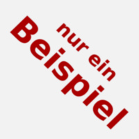

ein Beispielbild

###### vom lokalen Datenträger

```
![Windenergieanlagen](wind-power.png "Eine Handvoll WEA.")
```

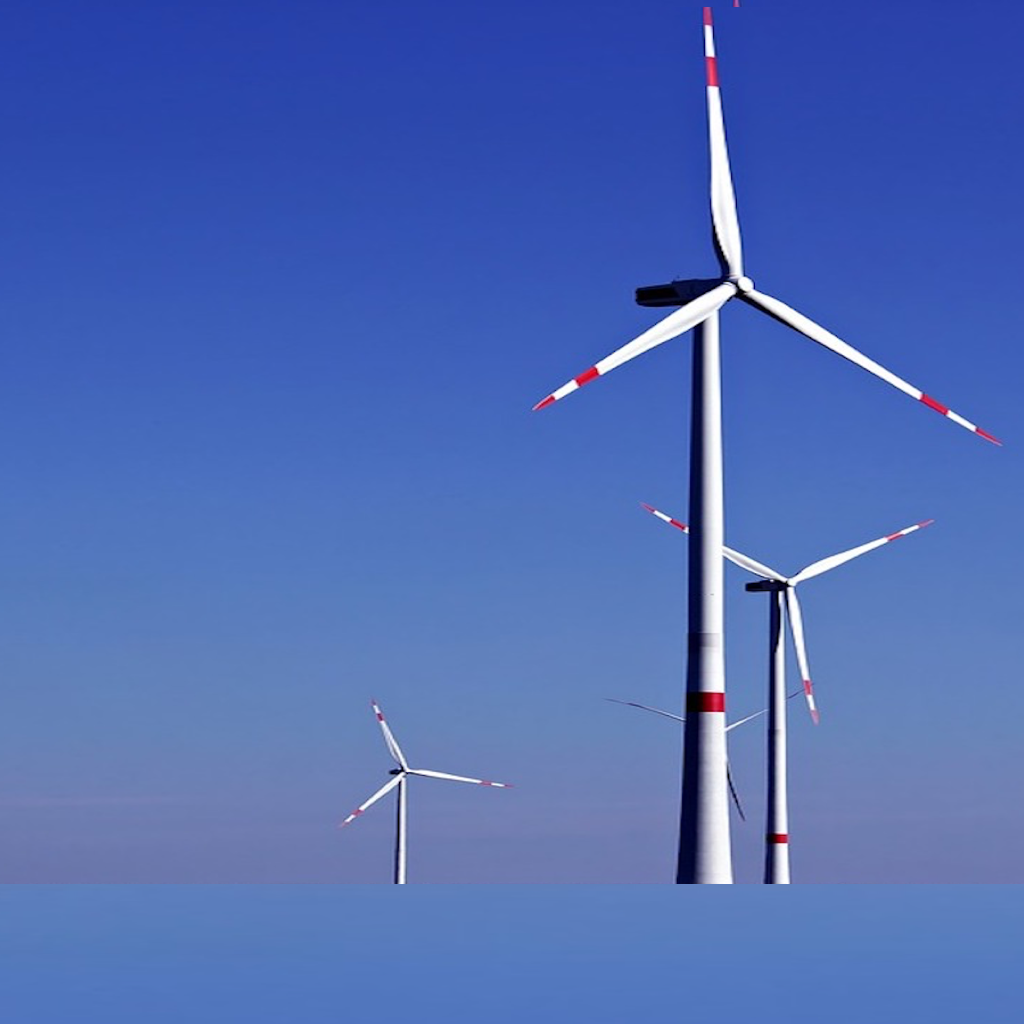

Windenergieanlagen

Soweit, so gut. Das ist schon fast alles, was man wissen muss, um mit Markdown Dokumente zu strukturieren und formatieren.

> “Aber all das kann ich auch mit Word oder PowerPoint”

wirst du jetzt erwidern.  
Ja, stimmt, aber wir sind ja auch erst am Anfang.